# DM Week 3 Quiz on Random Forest Solutions

# Problem Statement

## The data contains a random subset of the Arizona Medicare data for patients hospitalized subsequent to undergoing a CABG (DRGs 106, 107) or PTCA (DRG 112) cardiovascular procedure. You are hired to analyze whether the procedure will endanger the life of the patient or not. The target variable in the dataset is 'died'. Answer the following questions, in order, to complete this task.

A data frame with 1959 observations on the following 6 variables.

- died (target variable)
- procedure

1=CABG; 0=PTCA

- gender

1=male; 0=female

- age

age of subject

- los

hospital length of stay

- type

1=emerg/urgent; 0=elective

```python
# Required Imports
import pandas as pd
import numpy as np
import matplotlib.pyplot as plt
import seaborn as sns
from sklearn.model_selection import train_test_split
from sklearn import metrics
from sklearn.ensemble import RandomForestClassifier
```

```python
import sklearn #version check
sklearn.__version__
```

```
'0.23.1'
```

```python
# Importing Dataset
df = pd.read_csv('azcabgptca.csv').drop('Unnamed: 0',axis=1)
```

```python
df.head()
```

|  | died | procedure | age | gender | los | type |
| --- | --- | --- | --- | --- | --- | --- |
| 0 | 0 | 1 | 73 | 0 | 51 | 0 |
| 1 | 0 | 0 | 67 | 0 | 30 | 1 |
| 2 | 0 | 1 | 69 | 0 | 43 | 0 |
| 3 | 0 | 1 | 65 | 0 | 32 | 0 |
| 4 | 0 | 1 | 79 | 0 | 42 | 1 |

**Checking the target variable's classes**

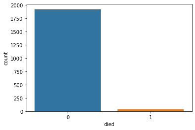

```python
sns.countplot(df.died);
# too much imbalance; do not worry, in the ML course, we will teach you how to deal with this
```

**Checking Null**

```python
df.isnull().sum()
```

```
died         0
procedure    0
age          0
gender       0
los          0
type         0
dtype: int64
```

# Make a RF model using random_state=0 and n_estimators=500. Fit the model on train data and predict on the train and test both. Splitting of data to be at test_size= 0.30 with random_state=0

# What is the model score for training & testing set ?

[take round up to 2 decimal places]

**Split the data**

```python
# Seperating the Dependent and Independent Variables
# 'target' is the indicator of presence of heart disease, hence it is the Dependent Variable
X = df.drop("died" , axis=1)

y = df['died']
```

```python
# splitting data into training and test set for independent attributes
from sklearn.model_selection import train_test_split

X_train, X_test, train_labels, test_labels = train_test_split(X, y, test_size=.30, random_state=0)
```

```python
rfcl = RandomForestClassifier(n_estimators = 500,random_state=0)
rfcl.fit(X_train, train_labels)
```

```
RandomForestClassifier(n_estimators=500, random_state=0)
```

```python
print('Training Set Score',round(rfcl.score(X_train,train_labels),2))
print('Testing Set Score',round(rfcl.score(X_test,test_labels),2))
```

```
Training Set Score 0.99
Testing Set Score 0.99
```

# Which of the following is the confusion Matrix (plotted) for the testing set?

```python
metrics.confusion_matrix(test_labels,rfcl.predict(X_test))
```

```
array([[575,   2],
       [  6,   5]], dtype=int64)
```

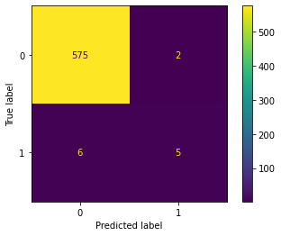

```python
metrics.plot_confusion_matrix(rfcl,X_test,test_labels);
```

# What is the ROC Area Under the Curve Score for the testing set?

[Upto 2 decimal places]

```python
print('ROC AUC Score for Testing Set',round(metrics.roc_auc_score(test_labels,rfcl.predict_proba(X_test)[:,1]),2))
```

```
ROC AUC Score for Testing Set 0.79
```

```
<sklearn.metrics._plot.roc_curve.RocCurveDisplay at 0x1e6195a42c8>
```

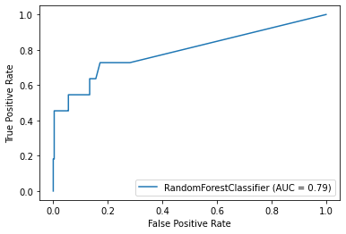

```python
metrics.plot_roc_curve(rfcl,X_test,test_labels) #another way
```

# What is the Precision and Recall for the patients who have died?

[Use Testing Set]

```python
print(metrics.classification_report(test_labels,rfcl.predict(X_test)))
```

```
              precision    recall  f1-score   support

           0       0.99      1.00      0.99       577
           1       0.71      0.45      0.56        11

    accuracy                           0.99       588
   macro avg       0.85      0.73      0.77       588
weighted avg       0.98      0.99      0.98       588
```

# As per the predictions on the testing set, how many patients actually died but we predicted that they won't?

```python
#False Negatives
tn, fp, fn, tp=metrics.confusion_matrix(test_labels,rfcl.predict(X_test)).ravel()
```

```python
print('The number of patients who actually died but we predicted they wont die are', fn)
```

```
The number of patients who actually died but we predicted they wont die are 6
```

```
                                              Happy Learning
```